# Working with Data Assignment 1

## INTRODUCTION TO TASK 2

This task involves scraping data from the web using an API key provided by JCDecaux. This task uses the Dublin bicycle dataset, which has the latitute and longitude information of every bike stand address. Information such as how many bike stands are available in that address, with the available number of bikes at that instance can also be obtained.

```r
# assign the token key to a variable
library(httr)
myKey <- 'f8db9e006c79016563757d26efdb069ed52ab060'

url <- 'https://api.jcdecaux.com/vls/v1/stations?'

response <- GET(url, query = list(apiKey = myKey,contract='dublin'))

result <- httr::content(response)

bicycleData <- data.frame(NULL)
len<-length(result)
for(i in 1:len){
  dataframe1<-data.frame(result[i])
  bicycleData <- rbind(bicycleData,dataframe1)
}

dplyr::summarise(bicycleData, count=n(), min=min(bicycleData$bike_stands), mean=mean(bicycleData$bike_stands), median=median(bicycleData$bike_stands), sd=sd(bicycleData$bike_stands),max=max(bicycleData$bike_stands))
```

```
##   count min     mean median       sd max
## 1   114  16 32.05263     30 7.532634  40
```

```r
# bicycle<-group_by(bicycleData,bicycleData$bike_stands) %>%
#   summarise(count=n(), mean=mean(bicycleData$bike_stands), median=median(bicycleData$bike_stands), sd=sd(bicycleData$bike_stands),max=max(bicycleData$bike_stands))
#
#
# sort(table(bicycleData$bike_stands))

##2.1
Bike_Stands <- dplyr::summarise(bicycleData, count=n(), total=sum(bicycleData$bike_stands),
                         min=min(bicycleData$bike_stands), mean=mean(bicycleData$bike_stands),
                         median=median(bicycleData$bike_stands), sd=sd(bicycleData$bike_stands),
                         max=max(bicycleData$bike_stands))

Available_Bike_Stands <- dplyr::summarise(bicycleData, count=n(), total=sum(bicycleData$available_bike_stands),
                                   min=min(bicycleData$available_bike_stands), mean=mean(bicycleData$available_bike_stands),
                                   median=median(bicycleData$available_bike_stands), sd=sd(bicycleData$available_bike_stands),
                                   max=max(bicycleData$available_bike_stands))

Available_Bikes <- dplyr::summarise(bicycleData, count=n(), total=sum(bicycleData$available_bikes), min=min(bicycleData$available_bikes), mean=mean(bicycleData$available_bikes),
                                   median=median(bicycleData$available_bikes), sd=sd(bicycleData$available_bikes),max=max(bicycleData$available_bikes))
Available_Bikes
```

```
##   count total min mean median       sd max
## 1   114  1368   0   12     11 8.345419  38
```

```r
sort(table(bicycleData$available_bikes))
```

```
##
##  1 23 24 25 26 27 28 32 34 38  9 17 19 21 30  3  6  7  8 13 16 18 20  2 11
##  1  1  1  1  1  1  1  1  1  1  2  2  2  2  2  3  4  4  4  4  4  4  4  5  5
## 22 10 12 14 15  0  5  4
##  5  6  6  6  6  7  8  9
```

```r
##Area1
Area1 <- subset(bicycleData, (bicycleData$position.lat>=53.33000 & bicycleData$position.lat<=53.33999))

Available_Bike_Stands_Area1 <- dplyr::summarise(Area1, count=n(), totalBikes=sum(Area1$available_bike_stands), min=min(Area1$available_bike_stands), mean=mean(Area1$available_bike_stands),
                                   median=median(Area1$available_bike_stands), sd=sd(Area1$available_bike_stands),max=max(Area1$available_bike_stands))

Available_Bikes_Area1 <- dplyr::summarise(Area1, count=n(), totalBikes=sum(Area1$available_bikes), min=min(Area1$available_bikes), mean=mean(Area1$available_bikes),
                             median=median(Area1$available_bikes), sd=sd(Area1$available_bikes),max=max(Area1$available_bikes))

##Area2

Area2 <- subset(bicycleData, (bicycleData$position.lat>=53.34000 & bicycleData$position.lat<=53.34999))


Available_Bike_Stands_Area2 <- dplyr::summarise(Area2, count=n(), totalBikes=sum(Area2$available_bike_stands), min=min(Area2$available_bike_stands), mean=mean(Area2$available_bike_stands),
                                   median=median(Area2$available_bike_stands), sd=sd(Area2$available_bike_stands),max=max(Area2$available_bike_stands))


Available_Bikes_Area2 <- dplyr::summarise(Area2, count=n(), total=sum(Area2$available_bikes), min=min(Area2$available_bikes), mean=mean(Area2$available_bikes),
                             median=median(Area2$available_bikes), sd=sd(Area2$available_bikes),max=max(Area2$available_bikes))

##Area3
Area3 <- subset(bicycleData, (bicycleData$position.lat>=53.35000 & bicycleData$position.lat<=53.35999))


Available_Bike_Stands_Area3 <- dplyr::summarise(Area3, count=n(), totalBikes=sum(Area3$available_bike_stands), min=min(Area3$available_bike_stands), mean=mean(Area3$available_bike_stands),
                                   median=median(Area3$available_bike_stands), sd=sd(Area3$available_bike_stands),max=max(Area3$available_bike_stands))


Available_Bikes_Area3 <- dplyr::summarise(Area3, count=n(), total=sum(Area3$available_bikes), min=min(Area3$available_bikes), mean=mean(Area3$available_bikes),
                             median=median(Area3$available_bikes), sd=sd(Area3$available_bikes),max=max(Area3$available_bikes))

##2.2

#A time-pressured individual cannot possibly scan through 114 area names at one go. It will be easier for them to view the information in an alphabetic order.

#Getting the first letter of the address
#Alphabet <- readline(prompt="Enter the first letter of the place you would like to search for: ")

#This function gets the alphabet specified in the params field on top. We can change the params to any other alphabet and the plot will be based on the value mentioned in params field. This is based on user input data.

readname = function()
{
  params$alphabet
}
Alphabet=readname()
Alphabet
```

```
## [1] "h"
```

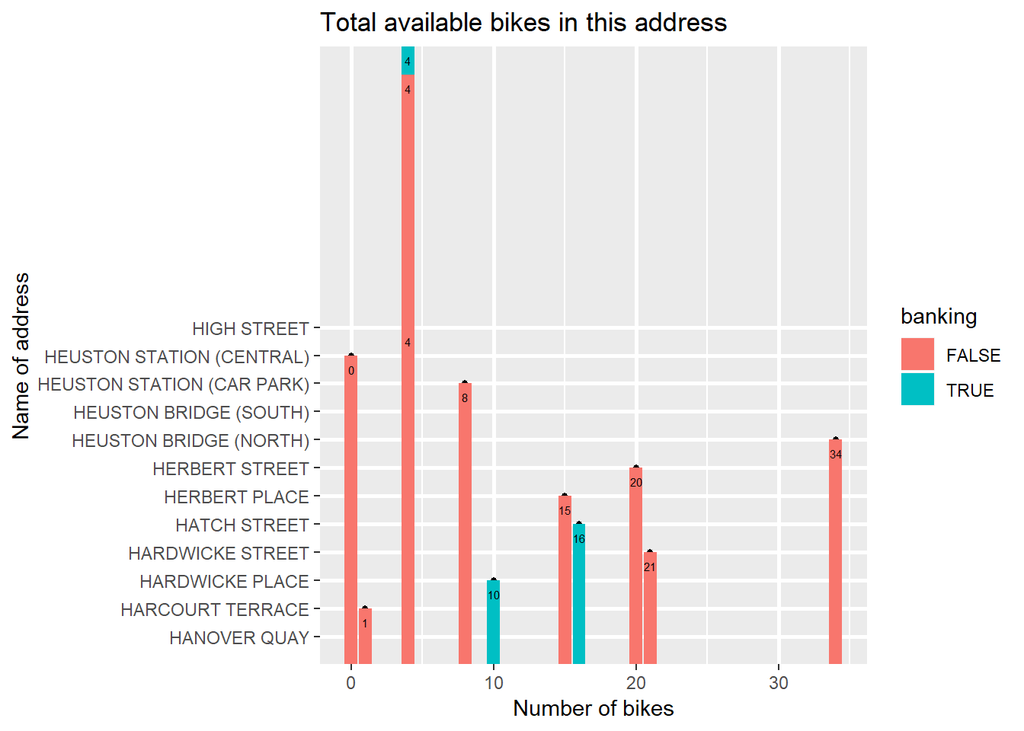

```r
AreaName <- subset(bicycleData, startsWith(as.character(bicycleData$name), substr(Alphabet, start=1,stop=1), ignore.case=TRUE))

##If an area exists with the given alphabet, a qplot will be displayed, else an error message will be displayed.

if(nrow(AreaName) > 0){
  qplot(data=AreaName,x=available_bikes,y=sort(as.character(name)), fill=banking, size=I(1), main = 'Total available bikes in this address', ylab='Name of address', xlab="Number of bikes")+ geom_bar(stat="identity") +theme(panel.grid = element_line(size = 1)) +geom_text(aes(label = available_bikes), size = 2, hjust = 0.5, vjust = 2, position ="stack")

}else{
  print('No such address exists. Please try again!!!')
}
```

Splitting the area into three regions based on their range of latitudinal positions, citizens can check which is the closest bike stand near them, that has bikes available to be used.

In area 1, total available bike stands are 620 and currently available bikes are 349. In area 2, total available bike stands are 1031 and currently available bikes are 722. In area 3, total available bike stands are 654 and currently available bikes are 268.

### Report on Task 2.2

A time-pressured individual cannot possibly scan through 114 area names at one go. It will be easier for them to view the information in an alphabetic order. Hence, I prompt the user to enter the first alphabet of the place they wish to see and will return the information of all the places that start with the alphabet they chose. The different colours are to distinguish if the bike stands have a banking facility or not.

These are the area names that starts with h, as specified in the params field: HANOVER QUAY, HATCH STREET, HARDWICKE PLACE, HERBERT PLACE, HIGH STREET, HERBERT STREET, HEUSTON STATION (CAR PARK), HEUSTON STATION (CENTRAL), HARDWICKE STREET, HEUSTON BRIDGE (SOUTH), HARCOURT TERRACE, HEUSTON BRIDGE (NORTH) that start with h .

Please specify any other alphabet in the params field and knit the rmd file again, a different plot will appear.